# Parima filmi Oscari ennustamine ajaloo põhjal

Risto Korb

15.05.2016

Olgu selleks siis võimalus omada eelist kihlveos või süütu huvi, alati võib kasuks tulla teadmine, kes või mis võiks teatud võistluse võita. Spordivõistlusel üldiselt sõltub tulemus võistlejatest kohapeal ja nende hetkeline võimekus. Seetõttu on keeruline ennustada võitjat, ilma võistleja tausta teadmata. Kui tegemist pole aga spordivõistlusega, siis võib eksisteerida olukord, kus sooritused on juba tehtud ja hindamisel ei kasutata mingisugust mõõdupuud vaid hindajate subjektiivset arvamust. Näiteks Eurovisiooni lauluvõistlusel on vähamlt kuu aega ette teada kõigi võistlejate laulud ja ka umbkaudne lavakava, enne kui hindama hakatakse. Sarnane süsteem toimub ka Oscarite filmigalal: nominendid on üldiselt publikule (või vähemalt kriitikutele) teada ning nähtu põhjal võib ennustada võitjaid. Kuid kui pole võimalik filmi ennast analüüsida ning on käepärast vaid arvulised näitajad ja teiste arvamused, tuleb ennustamisel appi ajalugu. Käesoleva projekti eesmärgiks on üritada ennustada, milline film võiks nominentide seast võita parima filmi tiitle.

Sellise ülesande lahendamisel tuleb alati alustada küsimusest: mis üleüldse mõjutab uuritavat tunnust. Antud juhul on´uuritavaks tunnuseks tõenäosus filmi Oscari võitmiseks. Oscari võitja tegelikkuses otsustatakse hääletuse läbi, kus hääletajateks on üldjuhul vastava auhinnaga seotud spetsialistid. See tähendab, et parima stsenaariumi poolt hääletavad üldiselt stsenaristid, parima montaaži auhind otsustatakse monteerijate poolt jne. Lisaks enda valdkonnas hääletamisele on spetsialistidel võimalus anda oma hääl sellele filmile, mis nende arust vääriks parima filmi auhinda.

Kuna spetsialistide hääl baseerub reaalsuses vaid nende sisetundele, mida pole võimalik mingil meetodil ennustamisvalemisse lisada, siis pole võimalik täpset hinnangut võitmiseks saada. Küll aga on võimalik umbkaudsetel meetoditel hinnata seda, mida hääletajad võiksid arvata. Siinkohal on hea ära kasutada seda, et arvamust ei avalda vaid mingi konkreetse valdkonna esindajad vaid kõik erinevate filmivaldkondadega seotud inimesed. See tähendab, et parima filmi auhind on otustatud varieeruva kultuuritaustaga inimeste poolt, kes kõik on filmindusega seotud. Sama võiks öelda ka üldise vaatajaskonna kohta, kes on teinud nii palju, et andnud oma hinnangu filmile mingisuguses portaalis. Käesolevas projektis on kasutatud rahvaarvamuse portaalina veebilehekülge IMDb.com (Internet Movie Database), kus annavad filmidele hääli miljonid inimesed, jättes sinna sageli ka lisaks kümne palli süsteemis vastavale hindele oma arvustuse, mis selgitaks nende hinnangut.

Tõenäoliselt ei piisa ühe filmiportaali kasutajatest, et luua adekvaatne hinnang spetsialistide arvamusele. Nimelt hindajad võivad filmides näha midagi sellist, mis tavavaataja silmist mööda läheb. Seetõttu tuleb mõelda veel tunnuseid, mis võiks mõjutada uuritavat tulemust.

Parima filmi Oscar antakse üle filmi produtsentidele. Produtsendid on need vastatuvad inimesed, kes teevad kindlaks, et film valmis saaks. Seetõttu on produtsendid ka need inimesed, kellele filmiauhind üle antakse. Võiks arvata, et mida rohkem on filmiprodutsendid tunnustatud, seda suurema tõenäosusega kordavad nad enda saavutust ja saavad Oscariga premeeritud.

Lisaks võib filmide arvamust peegeldada filmi sissetulek ja selle eelarve. Võiks arvata, et mida suurem on eelarve, seda paremaks film kujuneb ning mida suurem on filmi sissetulek, seda enam meeldib see vaatajatele.

Nende eelnevalt kirjeldatud tunnuste põhjal on üritatud hinnata, milline nominentidest võiks võita aasta filmi Oscari. Ehk siis uurija on püüdnud hinnata aasta filmi Oscari võitmise tõenäosust kasutades IMDb kasutajate hinnangut, produtsentide ajalugu ning eelarvet ja käivet. Statistiline mudel uuritava tunnuse hindamiseks on tehtud aastate 1991-2010 Oscarite võitjate ning nominentide baasil.

### Andmetabeli loomine

Alustuseks on võetud Wikipedia lehekülg, kus on välja toodud iga Oscarigala parima filmi nominendid koos võitjatega. Siin on välja toodud ka nominentidele vastavad produtsendid. Selle teadmise abiga on tekstitöötluse läbi loodud funktsioon, mis etteantud Oscarigaalade korral väljastab, millised produtsendid on mitu korda Oscarile nomineeritud ja mitu korda on nad võitnud. Seda funktsiooni väljastust kasutatakse andmete loomisel hiljem. Samuti on Wikipedia leheküljelt võetud filmide pealkirjad, mida edaspidi kasutati IMDb otsingumootoris.

IMDb-s on kasutatud liitotsingut, sest sama pealkirjaga filme võib olla mitu. Probleem tekkis näiteks filmiga “Beauty and the Beast”, mis 64. Oscarigalal oli nomineeritud parima filmi kategoorias. Kui aga IMDb lihtotsingusse lisada “Beauty and the Beast”, siis esimese vastena saadakse 2017. aastal ilmuv samanimeline mängufilm. Seetõttu, et valesid vastuseid mitte saada, kitsendatakse otsinguid sellega. Nimelt otsitakse ainult filme, mis on Oscarile nomineeritud, ning mis on välja ilmunud Oscarigalaga samal aastal ja aasta varem. Sellise kitsenduse korral puudub võimalus, et saadakse vale vastuseks vale film. Küll aga ei pruugi filmi pealkirjad Wikipedias ja IMDbs kattuda. Selle probleemi lahendust tutvustatakse hiljem.

Olles saanud IMDb otsingumootri kaudu sobivad vasted valib R-i programm neist esimese ja hangib informatsiooni vastava filmi IMDb leheküljelt. Filmi IMDb leheküljelt on lisatud tabelisse IMDb reiting; lisanud filmi lehekülje URLi lõppu /business kraabiti eelarve ja sissetuleku suurus; lisaks, lisanud lehekülje URLi lõppu /reviews, on programm loodud selliselt: valib 10 kõige paremini hinnatud arvustust (eeldusel, et neid on nii palju); kasutades “sentimentaalset” analüüsi (Sentimental analysis), arvutanud arvustuste polaarsuse. Polaarsus hindab teksti positiivsete ja negatiivsete sõnade põhjal, millise meeleoluga tekst võiks olla. Mida suurem number, seda positiivsem. Idee selle lisamise taga seisneb selles, et võiks arvata, et mida “parem” film, seda parema polaarusega filmi arvustused on. Samas tuleb mainida, et kui tegemist on väga hästi tehtud kurva filmiga (näiteks “Titanic”), siis võivad filmist kaasnevad kurvad emotsioonid olla arvustuses mainitud, suurendades sellega negatiivset polaarsust.

Lisaks tuleb mainida nii käibe kui ka arvustuste kohta, et andmetabeli loomisel ei ole kontrollitud, kas arvustus on kirjutatud enne vastavate Oscarite välja andmist ning käibena on võetud lõplikku käivet mitte suurust, mis oli saavutatud Oscarite jagamise hetkeks.

Kui mingil filmi andmete kättesaamisel esines probleeme (pealkirjade mittekattumine või informatsiooni lehekülgedel puudumine), siis eemaldas uurija need filmid. Kokku oli selliseid filme 7 (valimi suurus 109). Üldiselt oli nende filmide puhul tegemist väljaspool USAd tehtud filmidega, millele IMDb ei suutnud vastet leida Wikipedias leitava pealkirja põhjal.

Sissetuleku ja eelarve suuruseks proovis uurija kasutada ka Box Office Mojo andmebaase, kuid filmide üles leidmine sellest osutus tülikamaks kui IMDbs, ning seetõttu kasutati ainult viimast protaali.

### Saadud andmetabeli visuaalne analüüs

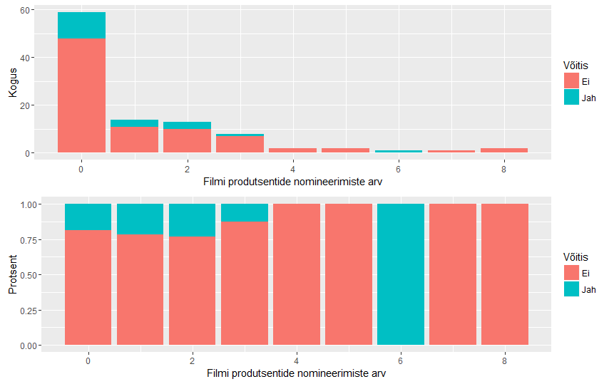

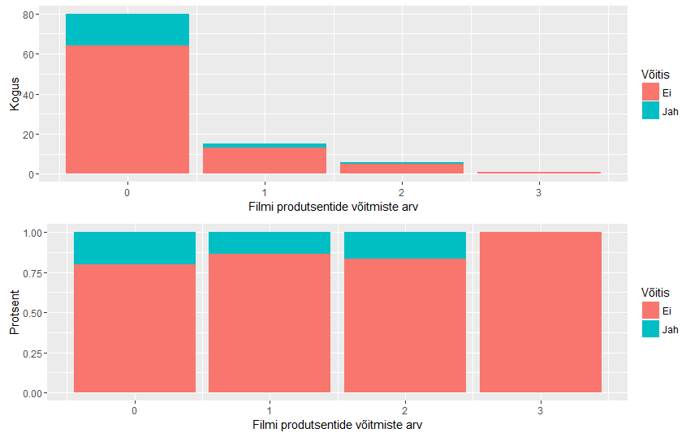

Vaadates, millise taustaga produtsendid on Oscari võitnud, tundub, et head šansid on vaid nende filmide produtsentidel, kes kokku on väga vähe kordi või üldse mitte Oscarile nomineeritud. Sama kehtib ka produtsentide Oscarite võitude kohta. Kui esmapilgul tundub, et leidub lineaarne (pöördvõrdeline) seos varem Oscaritele nomineerimise/võitmiste ja Oscari võitmise vahel, siis jooniselt võib näha, et eelnev lineaarne seos on petlik. Nimelt skaleerides andmed ümbel, et y-teljel oleksid koguse asemel protsentuaalne suhe võitmiste ja kaotamiste vahel, siis on näha, et antud andmete korral lineaarne seos puudub. Seega, luues lineaarset mudelit, võib osutuda, et vastavad tunnused on ebaolulised ja ei kirjelda andmestikku hästi.

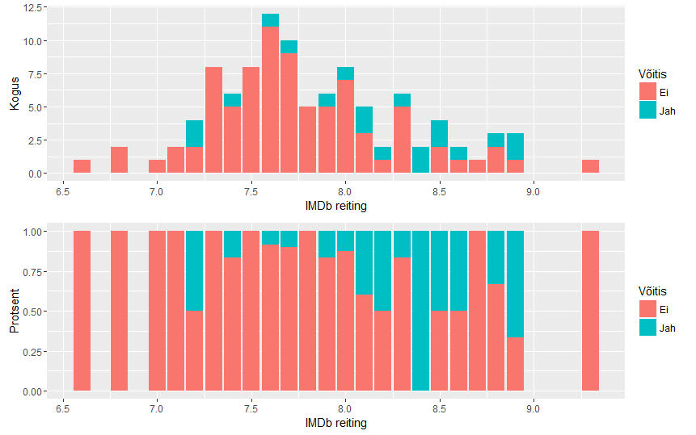

Järgnevalt püüame vaadelda, milline seos võiks leiduda IMDb kasutajate reitingu ja Oscari võidu vahel. Ka siin avaldame kaks joonist: esimesel on kujutatud y-teljel kogust ja teisel protsenti. Kui kõige suuremat suurust pidada erindiks, siis teise joonise põhjal võiks arvata, et hea reiting tagab ka suure tõenäosuse Oscari võita.

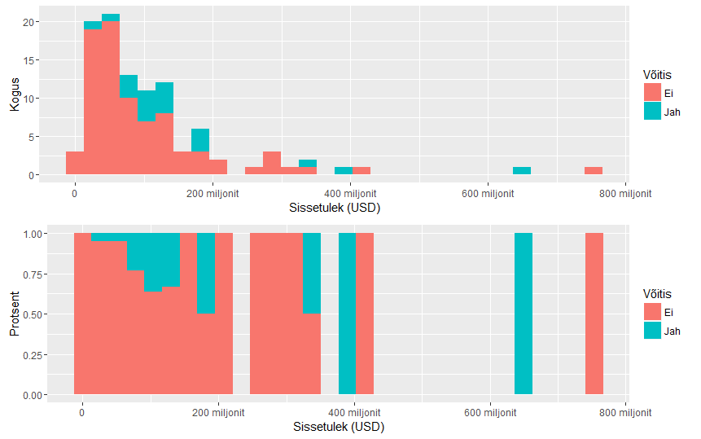

Kasutades andmeid filmide sissetuleku kohta võime jooniselt näha, et lineaarne seos puudub ja raske on praegusel vaatlusel hinnata ka mingi muu funktsiooniga sobilikumat varianti.

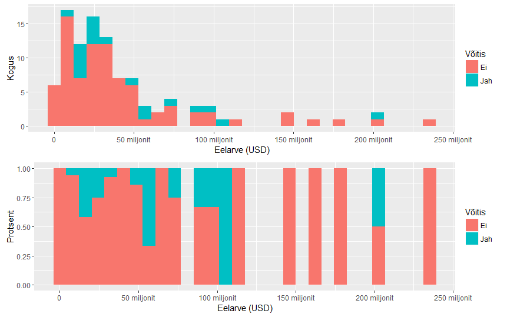

Eelnevale sarnaselt segast tulemust peegeldab ka joonis eelarve kohta. Siinkohal võiks arvata, et eelarve ja filmi käive ei kirjelda hästi tulemust.

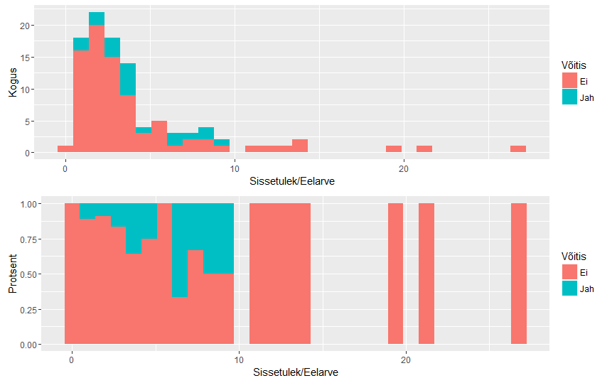

Küll aga on näha mingis vahemikus lineaarset suhet eelarve ja sissetuleku jagatise vahel: kuni sissetulek ei kümnekordista eelarve suurusst, siis võiks arvata, et eelarve ja sissetuleku suhe on võrdelises seoses võitmise tõenäosusega.

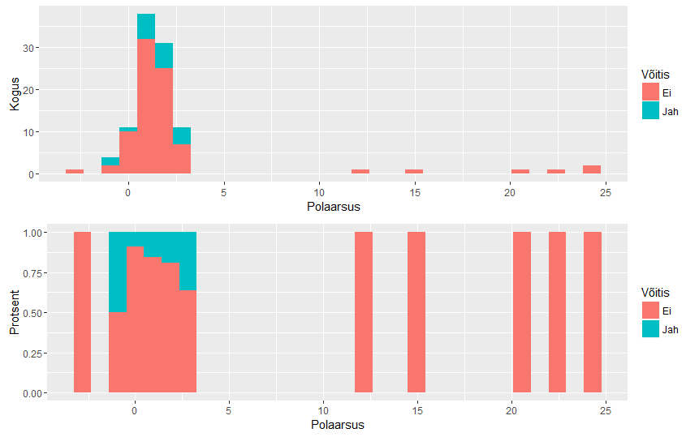

Viimaks analüüsitakse arvustuste polaaruse ja võitmise tõenäosuse vahel. Tundub, et kui polaarsus on kergelt negatiivne, siis on hea tõenäosus võitmiseks ja kui polaarsus on positiivne (kuid mitte väga tugevalt positiivne), siis on samuti tõenäosus võitmiseks hea.

### Mudeli loomine

Kasutades visuaalsel analüüsil saadud hinnanguid tunnuste ja võitmise tõenäosus seose vahel püüab uurija andmete põhjal koostada regressioonmudeli, lähtudes esialgu lineaarsetest argumentidest.

Mudeli loomisel alustatakse kõikidest põhitunnustest ning koosmõjudest järgnevate tunnuste vahel: produtsentide nominatsioonid ja produtsentide võidud; IMDb reitingud ja arvustuste polaarsus; sissetulek, eelarve ja sissetulek/eelarve. Seejärel nopiti välja ükshaaval (või paarikaupa) ebaolulised tunnused. Siinkohal mainib uurija, et olulisuse nivooks on võetud 0,25.

Esmasel mudelil osutus IMDb reiting ning sissetulek olulisteks tunnuseks. Ebaolulisteks osutusid üksteise järel: produtsentide võidud; sissetulek/eelarve; eelarve; produtsentide nominatsioonid. Lõplikku mudelisse jäid olulisteks tunnusteks sissetulek, IMDb reiting, arvustuste polaarsus ja viimase kahe koosmõju.

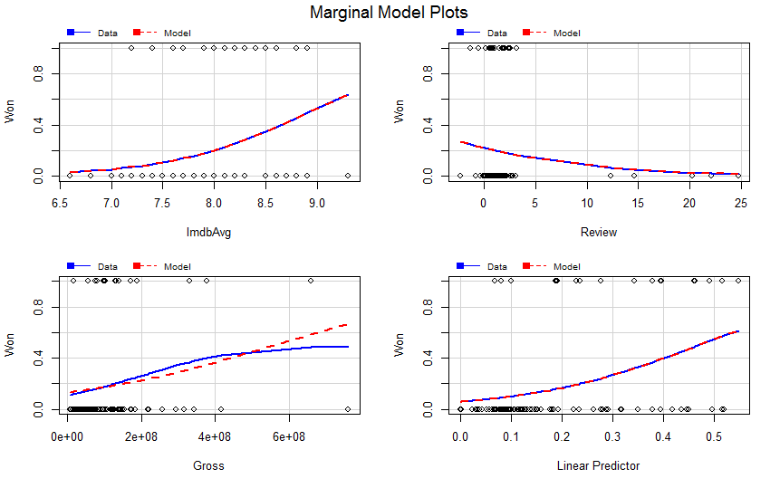

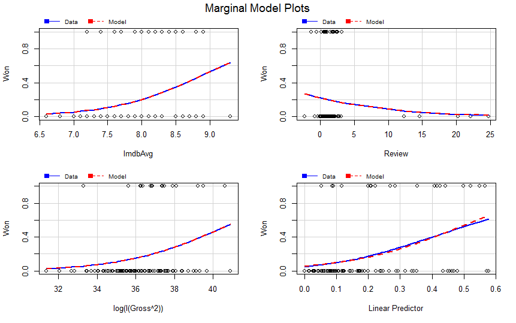

Marginaal mudeli graafik on graafik, mis üritab läbi pideva joone hinnata, milline seos võiks andmetel reaalsusega olla. Katkendjoon aga näitab seda, kuidas kirjeldab andmeid mudel. Selle graafiku põhjal on näha, et lineaarne funktsioon ei kirjelda sissetuleku ja võidu vahelist seost kõige pareimini. Testimise järel osutus andmestikku paremini kirjeldama logaritmfunktsion sissetuleku ruudust (log(Gross^2)). Lõplikule mudelile vastavat marginaal mudeli graafikut on võimalik näha all.

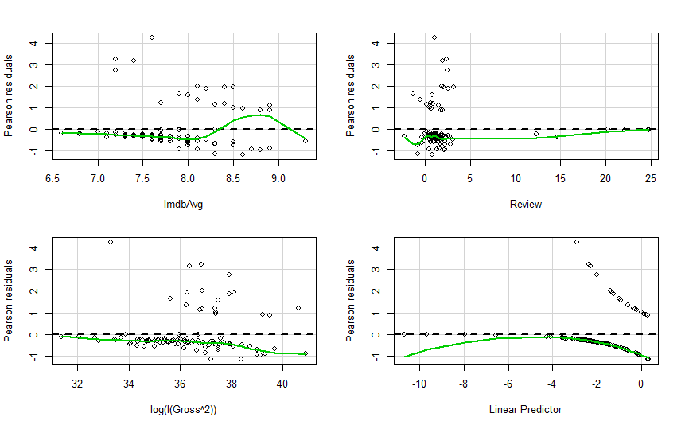

Jääkide graafiku põhjal võiks arvata, et leidub isegi parem funktsioon, mis kirjeldab teatud vaatluste hulka paremini. Seda sellepärast, et ideaalis on jääkide graafikul vaatlustele vastavad punktid ühtlaselt ümber punktiirjoone hajunud. Kahjuks ei suutnud uurija välja selgitada funktsiooni, mis jääkide hajuvust ühtlasemaks muudaks.

### Lõplik mudel ning selle interpreteetimine

Lõplikuks mudeliks osutus:

$log(frac{p}{1-p}) = -27 + 1.959*ImdbKeskmine + 3.428*Polaarusus + 0.311*log(Sissetulek^2) - 0.474*ImdbKeskmine*Polaarsus,$

### Testimine reaalsete tulemustega

Olles jõudnud lõpliku mudelini, tuleks selle efektiivsust testida reaalsete andmetega. Kuna Oscarite galat ei saa genereerida, oleme jätnud viimaste aastate tulmused arvestamata (mudeli jaoks on andmed kasutatud aastatest 1991-2010). Seega rakendatakse saadud mudelit nüüd aastate 2011-2014 parima filmi nominetidele. Kuna taas polnud võimalik kraapida täielik andmestik, jäeti ära puudulike andmetega read. Õnneks polnud nende seas ühtegi Oscari võitjat.

NB: Järgnevad protsendid on $p$ väärtused mudelitest, mitte reaalsed tõenäosused konkreetse gala võitmiseks.

#### 2011

Võitja meie mudeli põhjal:

1. The Help (29%)

Tegelik võitja:

6. The Artist (8%)

#### 2012

Võitja meie mudeli põhjal:

1. Django Unchained (52%)

Tegelik võitja:

2. Argo (26%)

#### 2013

Võitja meie mudeli põhjal:

1. The Wolf of Wall Street (40%)

#### 2014

Võitja meie mudeli põhjal:

1. The Imitation Game (21%)

Tegelik võitja:

3. Birdman (17%)

Kui 2011 aasta võitjaennustus välja arvata, siis suutis saadud mudel ennustada Oscari võitja TOP 3 sekka. Kahjuks polnud mudel piisav antud andmete korral ennustada võitjat, kuid algus seegi.

### Kokkuvõte

Üritades ennustada Oscari võitjat rahva poolt antud reitingute, arvustuste, filmi eelarve ja sissetuleku ning ka filmiprodutsentide tunnustuse põhjal, saavutati mudel, mis enamjaolt suudab asetada nomineeritud filmid sellisesse järjekorda, kus tegelik võitja paikneb esikolmikus. Kas see on piisav, et mudelit enda heaks ära kasutada on igaühe ise otsustada.

Küll aga on algus tõenäoliselt piisav, et avada võimalusi mudeli parandamiseks. Antud mudeliga saadi teada, et spetsialistidest hääletajate arvamust on võimalik kirjeldada tavavaataja hinde põhjal. Kuna IMDb on üks mitmest filmiportaalist võib mudeli parandamisel tulla kasuks teiste portaalide hinded. Lisaks mõisteti, et on hääletajate arvamust peegeldab ka sissetuleku suurus. See tähendab, et mudeli parandamisel võib kasuks tulla mitte ainult summaarne sissetulek vaid sissetuleku trend või esilinastuste poolt sissetulekute summa.

Seega, saadud mudel küll ei pruugi kutsuda inimesi kihlvepunkritesse, kuid saadud informatsiooni alusel on hea üritada luua paremat, tõhusamat mudelid, mis ehk suure tõenäosusega ennustab ka gala parima filmi auhinna pälvijat.